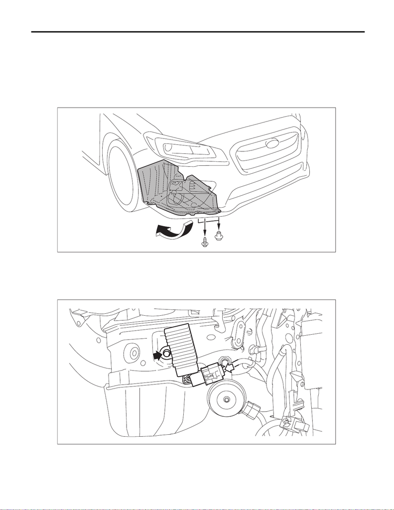

Day Time Running Resistor

LIGHTING SYSTEM

40.Day Time Running Resistor

A: REMOVAL

1) Disconnect the ground cable from battery. <Ref. to NT-5, BATTERY, NOTE, Note.>

NOTE:

For models other than STI model, disconnect the ground terminal from battery sensor.

2) Lift up the vehicle.

3) Remove the screw and clips, and turn over the front side of the mud guard - front.

4) Remove the resistor assembly - daytime running light.

CAUTION:

The resistor may become hot. Be careful not to burn yourself when removing it.

(1) Disconnect the connector.

(2) Remove the bolts, then remove the resistor assembly - daytime running light.

LI-01750

LI-01753

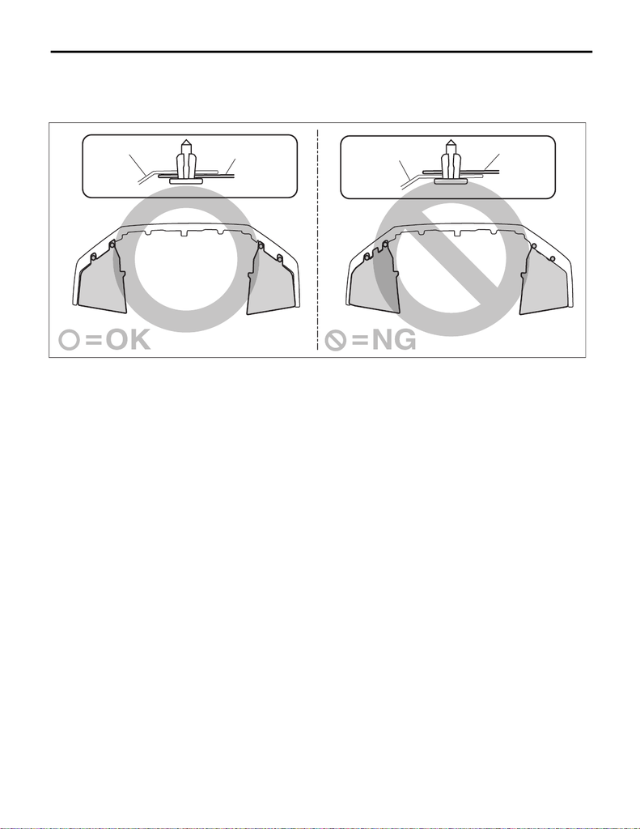

Day Time Running Resistor

LIGHTING SYSTEM

B: INSTALLATION

CAUTION:

front (a).

1) Install the resistor assembly - daytime running light.

Tightening torque:

7.5 N·m (0.8 kgf-m, 5.5 ft-lb)

2) Install the mud guard - front.

3) Lower the vehicle.

4) Connect the battery ground terminal. <Ref. to NT-5, BATTERY, NOTE, Note.>

NOTE:

For models other than STI model, connect the ground terminal to battery sensor.

COM00136

(a)

(b)

(a)

(b)